# Perception of Facts During the 2016 Election

Steven Friedman

## 1. Background

In the era of [“alternative facts,”](https://en.wikipedia.org/wiki/Alternative_facts) different groups maintain different views on reality. This has demonstrable implications for politics, public health, etc., and it matters whether the American electorate believes that an election was free and fair or whether vaccines work. At the same time, Americans are consuming media in different ways. Social media is becoming a more prevalent source for political news, and echo chambers have ostensibly contributed to increased polarization on fact-based issues.

In this analysis, voters’ confidence in their understanding of political issues is reconciled with their understanding of the facts. For voters of different age groups, political affiliations, and social media habits, perception and reality are compared with respect to government, the economy, and misinformation. Attention was taken to compare views on objective facts as opposed to opinions or ethics.

## 2. Data

The data comes from the American National Election Studies’ [Data Center](https://electionstudies.org/data-center/). Specifically, it is the [2016 Time Series Study](https://electionstudies.org/data-center/2016-time-series-study/), the latest election cycle currently available. Interviews were conducted over the telephone and online. Further detail on methodology is provided by ANES.

## 3. Social Media Usage

Americans of all age groups use social media to get their political news, although it skews younger. Interestingly, most respondents use social media for political news either every day or never.

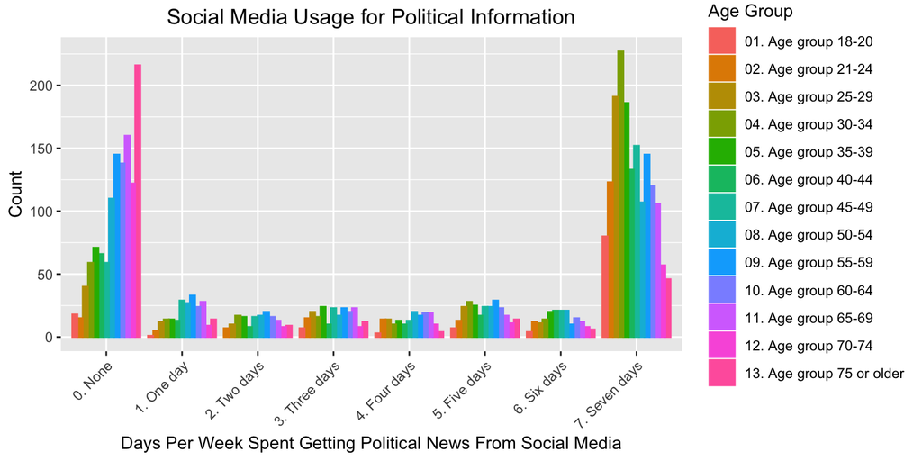

## 4. Who is the Most Confident?

Respondents were asked how much they would agree that they have a good understanding of political issues.

There is virtually no difference in the distribution of confidence across Clinton and Trump voters. Johnson and Stein voters tended to be less confident, but the sample sizes were much smaller.

[figure not shown]

There is no observable difference among the amount of days per week that individuals get political news on social media, although one might expect overconfidence for some groups.

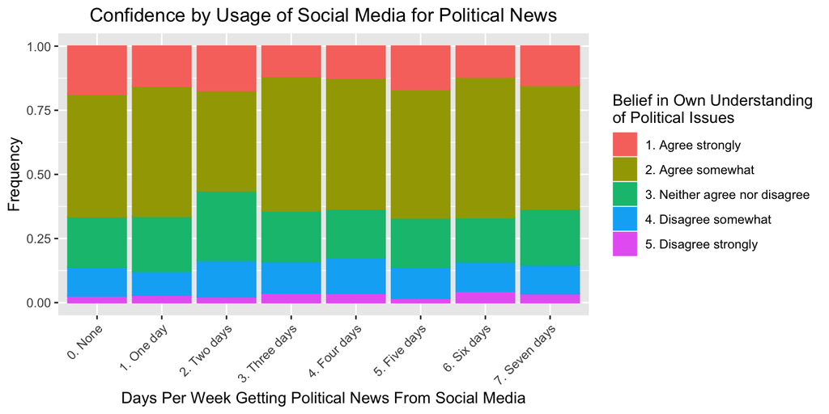

When we look at confidence across agre groups, we see a more meaningful trend. Older Americans feel they have a better understanding of political issues.

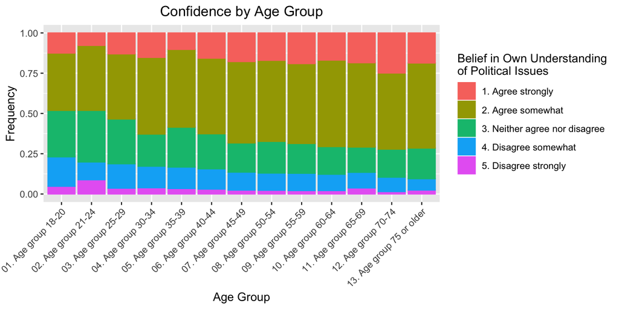

## 5. Who is Right More?

### 5.1. Politics

Respondants were asked if they knew who had more representation in the House of Representatives and the Senate at the time of the election. At that time, both were under Republican control.

The proportion of those who got both Houses of Congress correct is plotted below broken out by which candidate they voted for in the election and their age group. It appears that older voters are more politically aware as are Clinton voters.

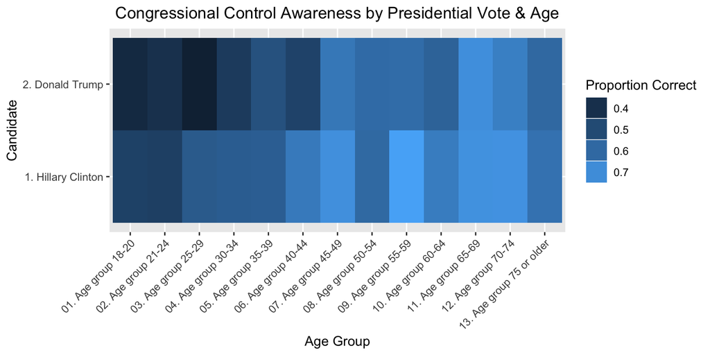

A similar analysis of social media usage over age groups shows no meaningful difference with respect to social media usage and awareness of this fact.

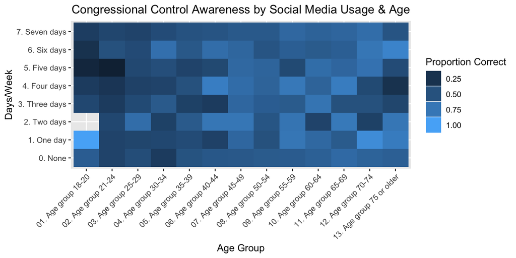

### 5.2. The Economy

Respondants were asked what the unemployment rate was at the time. They were given 4 choices. A noteworthy trend is that older voters tend to have a better idea of this economic indicator.

| Age group | 1. 2.9% | 2. 4.9% (correct) | 3. 6.9% | 4. 8.9% |
| --- | --- | --- | --- | --- |
| 01. Age group 18-20 | 8% | 52% | 25% | 15% |
| 02. Age group 21-24 | 6.21% | 49.15% | 29.38% | 15.25% |
| 03. Age group 25-29 | 3.03% | 58.33% | 28.41% | 10.23% |
| 04. Age group 30-34 | 5.81% | 49.85% | 29.97% | 14.37% |
| 05. Age group 35-39 | 4.85% | 55.02% | 26.86% | 13.27% |
| 06. Age group 40-44 | 4.42% | 62.39% | 23.01% | 10.18% |
| 07. Age group 45-49 | 4.3% | 56.27% | 25.45% | 13.98% |
| 08. Age group 50-54 | 6.92% | 57.79% | 26.64% | 8.65% |
| 09. Age group 55-59 | 5.23% | 61.16% | 25.07% | 8.54% |
| 10. Age group 60-64 | 6.33% | 66.46% | 21.52% | 5.7% |
| 11. Age group 65-69 | 2.61% | 64.5% | 25.41% | 7.49% |
| 12. Age group 70-74 | 5.13% | 58.97% | 25.64% | 10.26% |
| 13. Age group 75 or older | 6.87% | 61.07% | 20.61% | 11.45% |

Breaking out the same data by who respondants voted for in the 2016 election, we see that Trump voters are more likely than Clinton voters to overestimate the unemployment rate. This could be because of their opposition to Obama era policy and a worldview that the economy was worse off.

| Candidate | 1. 2.9% | 2. 4.9% (correct) | 3. 6.9% | 4. 8.9% |
| --- | --- | --- | --- | --- |
| 1. Hillary Clinton | 6.53% | 64.49% | 21.42% | 7.56% |
| 2. Donald Trump | 2.74% | 59.29% | 26.11% | 11.86% |
| 3. Gary Johnson | 6.36% | 58.18% | 27.27% | 8.18% |
| 4. Jill Steiin | 6.45% | 58.06% | 22.58% | 12.9% |

### 5.3. Misinformation

Survey respondents were asked if the believe that Barack Obama is Muslim, a piece of misinformation that had been circulating for years ahead of the 2016 election. Plotted here is the proportion in each bucket that are a little sure, moderately sure, very sure, or extremely sure of this incorrect belief.

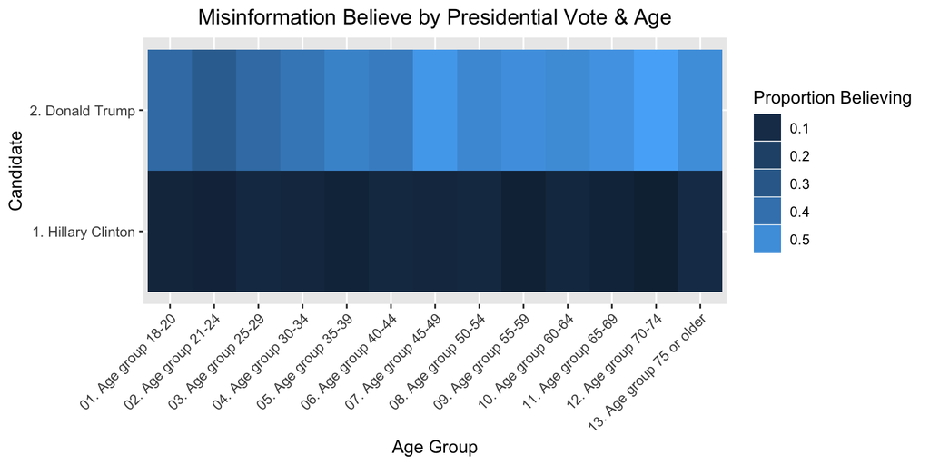

Note that social media usage doesn’t appear to be very important as opposed to age or party.

[figure not shown]

## 6. Conclusion

Although it may be easy to blame social media usage for misinformation, it doesn’t appear to be as good of a predictor of the population’s perception of reality. Rather, partisanship seems to be more important.

The reader should note that this sample may not be representative of the American electorate as a whole. The population of respondants may be different from the population surveyed, and the population surveyed may be different from the American electorate. Moreover, the survey was conducted over the Internet and over the phone, and these two methods may have yielded different populations or different answers, which is why ANES indicates which samples are from which survey.